# Statistica I

Esercitazione 5: covarianza, correlazione, regressione lineare semplice

Autore/Autrice

Affiliazione

Tommaso Rigon

DEMS

Alcuni dei problemi di questa esercitazione **non** sono stati svolti a lezione. Si consiglia agli studenti di provare a risolvere i problemi autonomamente.

## Tabacco e bevande alcoliche

I risultati di un’indagine del governo britannico sulla spesa delle famiglie possono essere utilizzati per investigare sulla relazione tra l’ammontare speso per i tabacchi e quello speso per le bevande alcoliche.

La seguente tabella riporta, per $n = 10$ regioni della Gran Bretagna, la spesa settimanale media per famiglia per i due capitoli di spesa, espressa in sterline. I dati sono riferiti al 1981.

| Regione | Alcolici | Tabacchi |
| --- | --- | --- |
| North | 6.47 | 4.03 |
| Yorkshire | 6.13 | 3.76 |
| Northeast | 6.19 | 3.77 |
| East Midlands | 4.89 | 3.34 |
| West Midlands | 5.63 | 3.47 |
| East Anglia | 4.52 | 2.92 |
| Southeast | 5.89 | 3.2 |
| Southwest | 4.79 | 2.71 |
| Wales | 5.27 | 3.53 |
| Scotland | 6.08 | 4.51 |

Si valuti la funzione di regressione tra le due variabili (usando la variabile `alcolici` come esplicativa).

### Schema della soluzione

In primo luogo disegniamo graficamente i dati tramite uno scatterplot

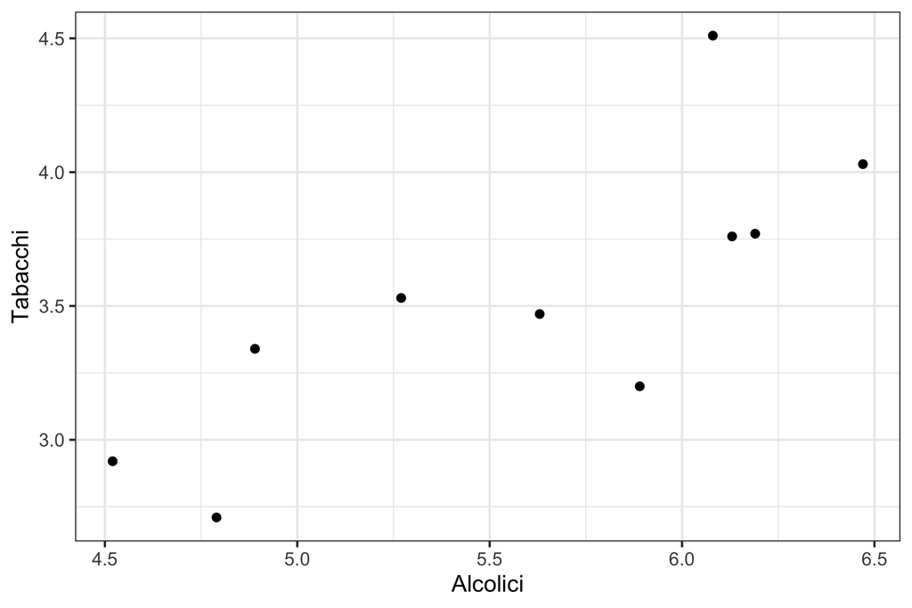

Valutiamo quindi le principali quantità d’interesse, dove $x_1,\dots,x_{10}$ rappresentano gli alcolici e $y_1,\dots,y_{10}$ rappresentano invece i tabacchi. Di conseguenza, avremo che:

$$\sum_{i=1}^nx_i y_i = 199.38, \qquad \sum_{i=1}^nx_i = 55.86, \qquad \sum_{i=1}^ny_i = 35.24.$$

È inoltre possibile calcolare le seguenti quantità

$$\sum_{i=1}^nx_i^2 = 316.169, \qquad \sum_{i=1}^ny_i^2 = 126.7.$$
Utilizzando le quantità del punto precedente, possiamo quindi ottenere la stima ai minimi quadrati $(\hat{\alpha},\hat{\beta})$ di un modello di regressione lineare semplice. In particolare, avremo che:

$$\hat{\beta} = \frac{\text{cov}(x,y)}{\text{var}(x)} = \frac{19.938 - 5.586\times 3.524}{31.617 - 5.586^2}= 0.611.$$
Si ha infatti che $\text{cov}(x,y) = 19.938 - 5.586\times 3.524 = 0.252936$ mentre $\text{var}(x) = 31.617 - 5.586^2 = 0.4136$. Inoltre avremo che:

$$\hat{\alpha} = \bar{y} - \hat{\beta} \bar{x} = \frac{35.24}{10} - 0.611\frac{55.86}{10} = 0.111.$$
I valori previsti si ottengono quindi tramite l’equazione:

$$\hat{y}_i = 0.111 + 0.611x_i.$$

Per comodità, riportiamo i valori previsti ed i residui nella seguente tabella

| $x_i$ | $y_i$ | $\hat{y}_i$ | $r_i$ |
| --- | --- | --- | --- |
| 6.47 | 4.03 | 4.06 | -0.03 |
| 6.13 | 3.76 | 3.86 | -0.10 |
| 6.19 | 3.77 | 3.89 | -0.12 |
| 4.89 | 3.34 | 3.10 | 0.24 |
| 5.63 | 3.47 | 3.55 | -0.08 |
| 4.52 | 2.92 | 2.87 | 0.05 |
| 5.89 | 3.20 | 3.71 | -0.51 |
| 4.79 | 2.71 | 3.04 | -0.33 |
| 5.27 | 3.53 | 3.33 | 0.20 |
| 6.08 | 4.51 | 3.83 | 0.68 |

Per valutare la bontà d’adattamento del modello usando l’indice $R^2$ si può procedere in due modi: i) calcolare il coefficiente di correlazione $\rho$ ed elevarlo al quadrato, oppure ii) attraverso il calcolo della varianza dei residui.

Dalla precedente tabella, so ottiene che $\text{var}(r) = n^{-1}\sum_{i=1}^n r_i^2 = 0.096$. Pertanto, otteniamo che

$$R^2 = 1 - \frac{\text{var}(r)}{\text{var}(y)} = 1 - \frac{0.096}{12.67 - 3.524^2} = 0.62.$$
Alternativamente avremmo potuto calcolare l’indice di correlazione
$$\rho = \frac{\text{cov}(x,y)}{\sqrt{\text{var}(x)}\sqrt{\text{var}(y)}} = \frac{0.2529}{\sqrt{0.4136 \times 0.2514}} = 0.78428.$$
E pertanto si otterà che $R^2 = \rho^2 = 0.62$. Concludiamo l’analisi rappresentano la retta di regressione sovrapposta ai dati.

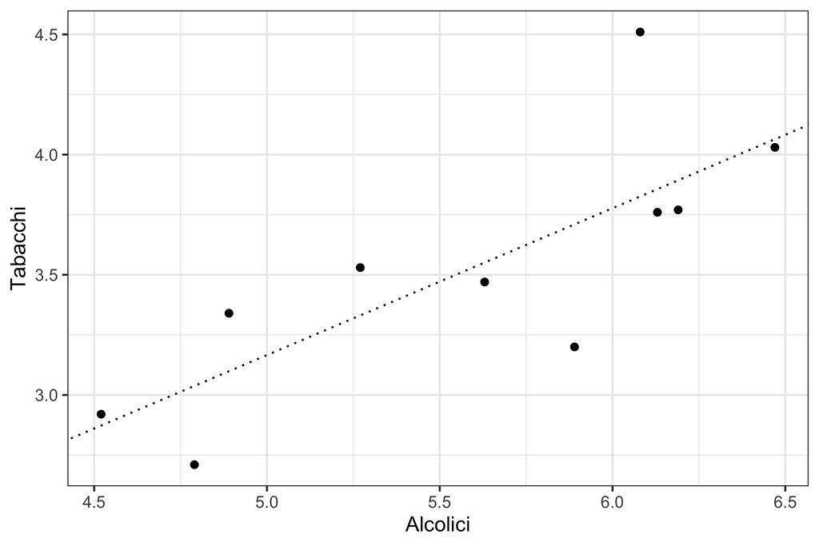

## Statura di padri e figli

La tabella che segue mostra le stature per un gruppo di padri e figli.

| Statura padre | Statura figlio |
| --- | --- |
| 165 | 167 |
| 170 | 169 |
| 180 | 181 |
| 172 | 171 |
| 179 | 180 |
| 174 | 176 |
| 176 | 180 |
| 168 | 171 |
| 181 | 179 |
| 173 | 174 |
| 170 | 173 |
| 178 | 176 |
| 176 | 178 |

Presupponendo una relazione lineare tra le stature dei padri e le stature dei figli, si dica che statura ci si aspetta per il figlio di un padre alto 170.5 cm.

### Schema della soluzione

In primo luogo disegniamo graficamente i dati tramite uno scatterplot

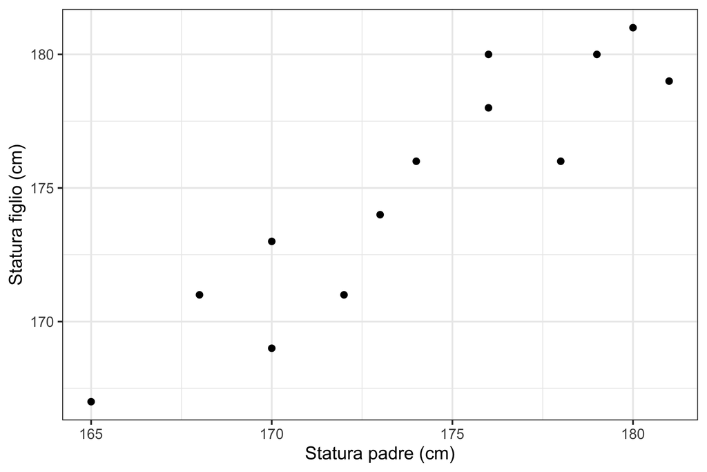

Valutiamo quindi le principali quantità d’interesse, dove $x_1,\dots,x_{13}$ rappresentano le stature dei padri e $y_1,\dots,y_{13}$ rappresentano invece le stature dei figli. Di conseguenza, avremo che:

$$\sum_{i=1}^nx_i y_i = 396096, \qquad \sum_{i=1}^nx_i = 2262, \qquad \sum_{i=1}^ny_i = 2275.$$

È inoltre possibile calcolare le seguenti quantità

$$\sum_{i=1}^nx_i^2 = 393876, \qquad \sum_{i=1}^ny_i^2 = 398375.$$
Utilizzando le quantità del punto precedente, possiamo quindi ottenere la stima ai minimi quadrati $(\hat{\alpha},\hat{\beta})$ di un modello di regressione lineare semplice. In particolare, avremo che:

$$\hat{\beta} = \frac{\text{cov}(x,y)}{\text{var}(x)} = \frac{30468.92 - 174\times 175}{30298.15 - 174^2}= 0.854.$$
Si ha infatti che $\text{cov}(x,y) = 30468.92 - 174\times 175 = 18.92$ mentre $\text{var}(x) = 30298.15 - 174^2 = 22.15$. Inoltre avremo che:

$$\hat{\alpha} = \bar{y} - \hat{\beta} \bar{x} = 175 - 0.854\times 174 = 26.404.$$
I valori previsti si ottengono quindi tramite l’equazione:

$$\hat{y}_i = 26.404 + 0.854 x_i.$$
Pertanto, il valore previsto cercato è pari a $26.404 + 0.854 \times 170.5 = 172.011$.